# Diversification

Kevin Crotty  
BUSI 448: Investments

## Where are we?

**Last time**:

- Short-selling and margin
- Equities lending
- Limits to arbitrage
- Short-selling regulation

**Today**:

- Diversification
- Efficient combinations of risky assets

## Portfolios: combinations of underlying assets

Given return properties of underlying assets, what are the return properties of their combination?

… and what’s the optimal way to combine the assets?

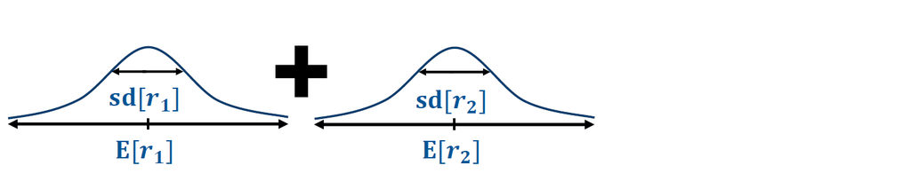

## Portfolios: combinations of underlying assets

Given return properties of underlying assets, what are the return properties of their combination?

… and what’s the optimal way to combine the assets?

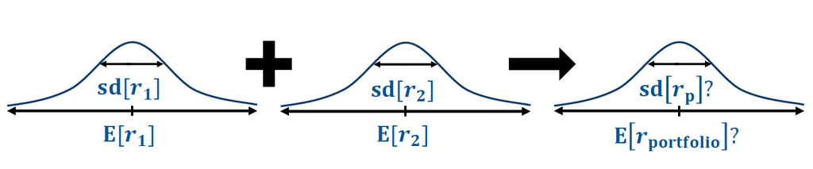

# Diversification

## What is diversification?

- Diversification is a foundational, and somewhat miraculous, concept in forming portfolios.
- ``don’t put all of your eggs in one basket.’’
- By combining assets together, we may be able to build a portfolio that has less risk than even the least risky asset we use as a building block!
- violation of the ``no free lunch’’ principle

## Portfolios of Two Risky Assets

- Let’s consider combining a domestic equity fund and a developed markets international equity fund.
- The return of a two-asset portfolio is the weighted sum of the returns of the underlying assets:
  $$r_p = w r_{\text{US}} + (1-w) r_{\text{intl}} \,,$$
  where $w$ is the portfolio weight in the domestic fund.
- The expected return of the portfolio is:
  $$E[r_p] = w E[r_{\text{US}}] + (1-w) E[r_{\text{intl}}] \,.$$

## Portfolio risk (Two risky assets)

- We will use either the portfolio variance or standard deviation as a measure of the portfolio’s risk.
- We can write the portfolio variance in terms of the individual asset variances and their covariance:
  $$w^2 \text{var}[r_{\text{US}}] + (1-w)^2 \text{var}[r_{\text{intl}}] + 2 w (1-w) \text{cov}[r_{\text{US}},r_{\text{intl}}]$$
- Alternatively, we can express the last term using correlation $\rho$:
  $$w^2 \text{var}[r_{\text{US}}] + (1-w)^2 \text{var}[r_{\text{intl}}] + 2 w (1-w) \rho \cdot \text{sd}[r_{\text{US}}]\text{sd}[r_{\text{intl}}]$$

## Diversification in action

[interactive chart not shown]

## Correlation and diversification

Lower correlation between assets results in greater potential diversification benefits.

[dashboard example](https://learn-investments.rice-business.org/portfolios/two-assets)

## Adding another risky asset

Let’s also consider investing in an emerging market fund.

**Expected return**:

$$E[r_p] = w_{\text{US}} E[r_{\text{US}}] + w_{\text{intl}} E[r_{\text{intl}}] + w_{\text{emerg}} E[r_{\text{emerg}}] \,,$$

where $w_i$ is the portfolio weight in asset $i$.

**Portfolio variance**:

$$\begin{align*}
\text{var}[r_p] =&w_{\text{US}}^2 \text{var}[r_{\text{US}}] + w_{\text{intl}}^2 \text{var}[r_{\text{intl}}] + w_{\text{emerg}}^2 \text{var}[r_{\text{emerg}}] \\
&+ 2 w_{\text{US}} w_{\text{intl}} \text{cov}[r_{\text{US}}, r_{\text{intl}}] \\
&+ 2 w_{\text{US}} w_{\text{emerg}} \text{cov}[r_{\text{US}}, r_{\text{emerg}}] \\
&+ 2 w_{\text{intl}} w_{\text{emerg}} \text{cov}[r_{\text{intl}}, r_{\text{emerg}}] \\
\end{align*}$$

## Possible three asset portfolios

[interactive chart not shown]

## Correlation and diversification: 3 risky assets

[dashboard](https://learn-investments.rice-business.org/portfolios/three-assets)

# Portfolios with Many Assets

## Portfolios with Many Assets

- Adding more securities to a portfolio results in additional diversification benefits
- The marginal benefit of an additional security decreases with the total number of securities in the portfolio.

$N$-asset portfolio variance:

$$\text{var}[r_p] = \sum_{i=1}^{N} w_i^2 \text{var}[r_i] + 2 \sum_{i=1}^{N} \sum_{j>i} w_i w_j \text{cov}[r_i,r_j]\,,$$

## Portfolio variance: matrix approach

Given a covariance matrix $V$:
$$\begin{equation*}
V =
\begin{bmatrix}
\text{var}[r_1] & \text{cov}[r_1,r_2] & \dots & \text{cov}[r_1,r_N] \\
\text{cov}[r_2,r_1] & \text{var}[r_2] & \dots & \text{cov}[r_2,r_N] \\
\vdots & \vdots & \ddots & \vdots \\
\text{cov}[r_N,r_1] & \text{cov}[r_N,r_2] & \dots & \text{var}[r_N] \\
\end{bmatrix}
\end{equation*}$$
and a vector of portfolio weights

$$w'=[w_1\, w_2\,...\,w_N]\,,$$

The portfolio variance is the matrix product:

$$\text{var}[r_p] = w'Vw \,.$$

## Effects of Diversification

Claim: The variance of the return of a portfolio with many securities depends more on the covariances between the individual securities than on the variances of the individual securities.

| $w_1^2 \text{var}[r_1]$ | $w_1 w_2 \text{cov}[r_1,r_2]$ | $w_1 w_3 \text{cov}[r_1,r_3]$ |
| --- | --- | --- |
| $w_2 w_1 \text{cov}[r_2,r_1]$ | $w_2^2 \text{var}[r_2]$ | $w_2 w_3 \text{cov}[r_2,r_3]$ |
| $w_3 w_1 \text{cov}[r_3,r_1]$ | $w_3 w_2 \text{cov}[r_3,r_2]$ | $w_3^2 \text{var}[r_3]$ |

## Now consider a five-security portfolio

| $w_1^2 \text{var}[r_1]$ | $w_1 w_2 \text{cov}[r_1,r_2]$ | $w_1 w_3 \text{cov}[r_1,r_3]$ | $w_1 w_4 \text{cov}[r_1,r_4]$ | $w_1 w_5 \text{cov}[r_1,r_5]$ |
| --- | --- | --- | --- | --- |
| $w_2 w_1 \text{cov}[r_2,r_1]$ | $w_2^2 \text{var}[r_2]$ | $w_2 w_3 \text{cov}[r_2,r_3]$ | $w_2 w_4 \text{cov}[r_2,r_4]$ | $w_2 w_5 \text{cov}[r_2,r_5]$ |
| $w_3 w_1 \text{cov}[r_3,r_1]$ | $w_3 w_2 \text{cov}[r_3,r_2]$ | $w_3^2 \text{var}[r_3]$ | $w_3 w_4 \text{cov}[r_3,r_4]$ | $w_3 w_5 \text{cov}[r_3,r_5]$ |
| $w_4 w_1 \text{cov}[r_4,r_1]$ | $w_4 w_2 \text{cov}[r_4,r_2]$ | $w_4 w_3 \text{cov}[r_4,r_3]$ | $w_4^2 \text{var}[r_4]$ | $w_4 w_5 \text{cov}[r_4,r_5]$ |
| $w_5 w_1 \text{cov}[r_5,r_1]$ | $w_5 w_2 \text{cov}[r_5,r_2]$ | $w_5 w_3 \text{cov}[r_5,r_3]$ | $w_5 w_4 \text{cov}[r_5,r_4]$ | $w_5^2 \text{var}[r_5]$ |

How many variance terms?

$$N=5$$

How many covariance terms?

$$N^2-N = 25-5=20$$

## Why does covariance dominate with large $N$?

- Consider an $N$-asset, equal-weighted portfolio $(w=1/N$)
- Assume all assets have the same variance $(\sigma^2_{\text{all}})$
- Assume all pairs of assets have the same covariance $(\overline{\text{cov}})$
- What is the variance of the portfolio?

$$\begin{align*}
\text{var}(r_p) =& N\cdot \left(\frac{1}{N}\right)^2 \sigma^2_{\text{all}} + (N^2-N)\cdot \left(\frac{1}{N}\right)^2 \overline{\text{cov}} \\
=& \left(\frac{1}{N}\right) \sigma^2_{\text{all}} + \left(\frac{N-1}{N}\right) \overline{\text{cov}}
\end{align*}$$

What happens to this as N gets large?

$$\text{var}(r_p) \underset{N\rightarrow \infty}{\longrightarrow} 0\cdot\sigma^2_{\text{all}}+(1-0)\overline{\text{cov}}=\overline{\text{cov}}$$

## Diversification curves

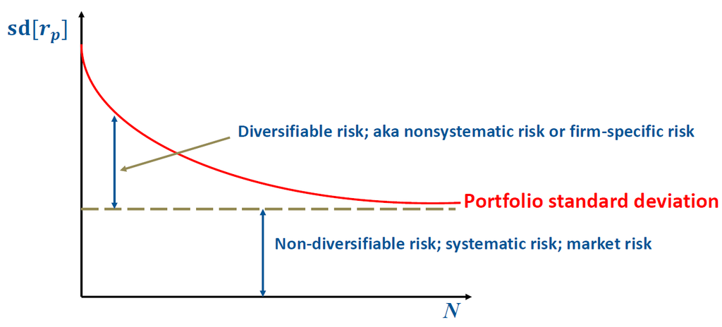

- Diversification eliminates some, but not all, of the risk of individual assets.
- In large portfolios, $\text{var}[r_i]$’s effectively diversified away, but not $\text{cov}[r_i,r_j]$’s.
- [dashboard](https://learn-investments.rice-business.org/portfolios/diversification)

# Short-selling and the opportunity set

## Short-Sales

What is the meaning of a negative portfolio weight?

- Negative portfolio weights correspond to short positions in a portfolio.
- For our discussion of portfolio optimization, we will ignore many practical issues (restrictions on using sales proceeds, fee paid to borrow asset, etc.)

## Allowing short sales

[interactive chart not shown]

# Efficient Frontier

## Efficient Frontier

- For a given target return, an efficient portfolio is the set of portfolio weights that minimize the portfolio’s risk (variance or standard deviation).

Mathematically, choose portfolio weights to solve the following constrained optimization problem for each target return $\mu_{\text{target}}$:

$$\underset{w_1,w_2,\dots,w_N}{\text{min}} \text{var}[r_p]$$

subject to constraints: $E[r_p]=\mu_{\text{target}}$ and $\sum_i w_i=1$

## Optimization in Python

The function `cvxopt.solvers.qp` solves problems of the general form:
$$\begin{align}
\underset{w}{\text{min }}& \frac{1}{2} w' Q w + p'w \\
\text{subject to } & Gw \le h \\
& Aw = b \\
\end{align}$$

## Finding a Frontier Portfolio: Parameters

```
##### Inputs
# Expected returns
MNS = np.array([0.06, 0.065, 0.08])

# Standard deviations
SDS = np.array([0.15, 0.165, 0.21])

# Correlations
C  = np.identity(3)
C[0, 1] = C[1, 0] = 0.75
C[0, 2] = C[2, 0] = 0.75
C[1, 2] = C[2, 1] = 0.75

# Covariance matrix
COV = np.diag(SDS) @ C @ np.diag(SDS)

# Target expected return
TARGET_EXP_RET = 0.07
```

## Finding a Frontier Portfolio: Optimization

```python
def frontier(means, cov, target):
    n = len(means)
    Q = matrix(cov, tc="d")
    p = matrix(np.zeros(n), (n, 1), tc="d")
    # Constraint: short-sales allowed
    G = matrix(np.zeros((n,n)), tc="d")
    h = matrix(np.zeros(n), (n, 1), tc="d")
    # Fully-invested constraint + E[r] = target
    A = matrix(np.vstack((np.ones(n), means)), (2, n), tc="d")
    b = matrix([1, target], (2, 1), tc="d")
    sol = Solver(Q, p, G, h, A, b)
    wgts = np.array(sol["x"]).flatten() if sol["status"] == "optimal" else np.array(n * [np.nan])
    return wgts
```

# GMV

## The Global Minimum Variance Problem

- The GMV portfolio is the portfolio of risky assets with the smallest variance.
- It is a set of portfolio weights that minimizes the portfolio variance.

Mathematically, choose portfolio weights to solve the following constrained optimization problem:

$$\underset{w_1,w_2,\dots,w_N}{\text{min}} \text{var}[r_{p}]$$

subject to constraints: $\sum_i w_i=1$

## GMV in Python

```python
def gmv(means, cov):
    n = len(means)
    Q = matrix(cov, tc="d")
    p = matrix(np.zeros(n), (n, 1), tc="d")
    # Constraint: short-sales allowed
    G = matrix(np.zeros((n,n)), tc="d")
    h = matrix(np.zeros(n), (n, 1), tc="d")
    # Constraint: fully-invested portfolio
    A = matrix(np.ones(n), (1, n), tc="d")
    b = matrix([1], (1, 1), tc="d")
    sol = Solver(Q, p, G, h, A, b)
    wgts = np.array(sol["x"]).flatten() if sol["status"] == "optimal" else np.array(n * [np.nan])
    return wgts
```

# For next time: Theory of Optimal Portfolios

BUSI 448